# Learning the topology of graphs

Convex Group-HKUST

2018-10-08

# Installation

For installation instructions, please visit https://github.com/dppalomar/spectralGraphTopology

# Problem Statement

The Laplacian matrix $\boldsymbol{\Theta}$ of a graph contains the information of its topology and weight connections. By definition a Laplacian matrix is positive semi-definite, symmetric, and with sum of rows equal to zero. The Laplacian linear operator $\mathcal{L}\mathbf{w}$ maps a vector of weights $\mathbf{w}$ into a valid Laplacian matrix so that the conditions are satisfied by construction.

Another classical approach was proposed in [1] which incorporates a $\ell_1$-norm penalty term in order to induce sparsity on the solution. The R package `glasso` provides an implementation of this estimator.

The underlying optimization problem of learning a K-component graph, solved by `spectralGraphTopology`, may be expressed as follows:
$$\begin{array}{ll}
\underset{\mathbf{w}, \boldsymbol{\Lambda}, \mathbf{U}}{\textsf{minimize}} & - \log \det(\boldsymbol{\Lambda})
+ \mathrm{tr}\left(\mathbf{K}\mathcal{L}\mathbf{w}\right)
+ \frac{\beta}{2}\big\|\mathcal{L}\mathbf{w} - \mathbf{U}\boldsymbol{\Lambda}\mathbf{U}^{T}\big\|^{2}_{F}\\
\textsf{subject to} & \mathbf{w} \geq 0, \boldsymbol{\Lambda} \in \mathcal{S}_{\boldsymbol{\Lambda}},~\text{and}~
\mathbf{U}^{T}\mathbf{U} = \mathbf{I}
\end{array}$$
where $\mathcal{S}_{\boldsymbol{\Lambda}}$ further constrains the eigenvalues of Laplacian matrices $\boldsymbol{\Theta}=\mathcal{L}\mathbf{w}$ according to some topology (e.g., a $K$-component graph has $K$ zero eigenvalues).

# Usage of the package

We illustrate the usage of the package with simulated data, as follows:

```r
library(spectralGraphTopology)
set.seed(123)

# Number of samples
T <- 200
# Vector to generate the Laplacian matrix of the graph
w <- runif(10)
# Laplacian matrix
Lw <- L(w)
# Sample data from a Multivariate Gaussian
N <- ncol(Lw)
Y <- MASS::mvrnorm(T, rep(0, N), MASS::ginv(Lw))
# Number of components of the graph
K <- 1
# Learn the Laplacian matrix
res <- learnGraphTopology(cov(Y), K, beta = 10)
```

Let’s visually inspect the true Laplacian and the estimated one:

```r
Lw
```

```
#>            [,1]       [,2]       [,3]       [,4]       [,5]
#> [1,]  2.3678770 -0.2875775 -0.7883051 -0.4089769 -0.8830174
#> [2,] -0.2875775  1.8017068 -0.9404673 -0.0455565 -0.5281055
#> [3,] -0.7883051 -0.9404673  3.1726265 -0.8924190 -0.5514350
#> [4,] -0.4089769 -0.0455565 -0.8924190  1.8035672 -0.4566147
#> [5,] -0.8830174 -0.5281055 -0.5514350 -0.4566147  2.4191726
```

```r
res$Lw
```

```
#>            [,1]       [,2]       [,3]       [,4]       [,5]
#> [1,]  2.2953931 -0.2707906 -0.6305267 -0.4159845 -0.9780912
#> [2,] -0.2707906  1.9513456 -1.0254774 -0.0612756 -0.5938020
#> [3,] -0.6305267 -1.0254774  2.9706229 -0.8389331 -0.4756856
#> [4,] -0.4159845 -0.0612756 -0.8389331  1.9175138 -0.6013206
#> [5,] -0.9780912 -0.5938020 -0.4756856 -0.6013206  2.6488995
```

Another visual tool is the correlation matrix:

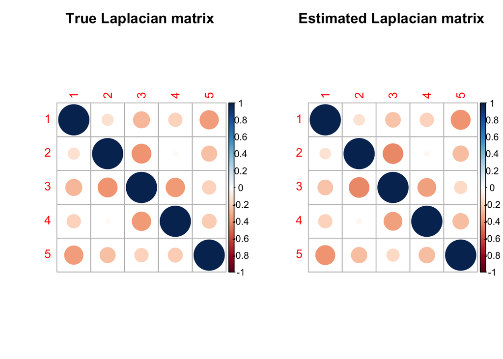

```r
library(corrplot)
par(mfrow = c(1, 2))
corrplot(cov2cor(Lw), mar = c(0, 0, 1, 0))
title("True Laplacian matrix", line = 2.5)
corrplot(cov2cor(res$Lw), mar = c(0, 0, 1, 0))
title("Estimated Laplacian matrix", line = 2.5)
```

Finally, we can also plot the graph structure:

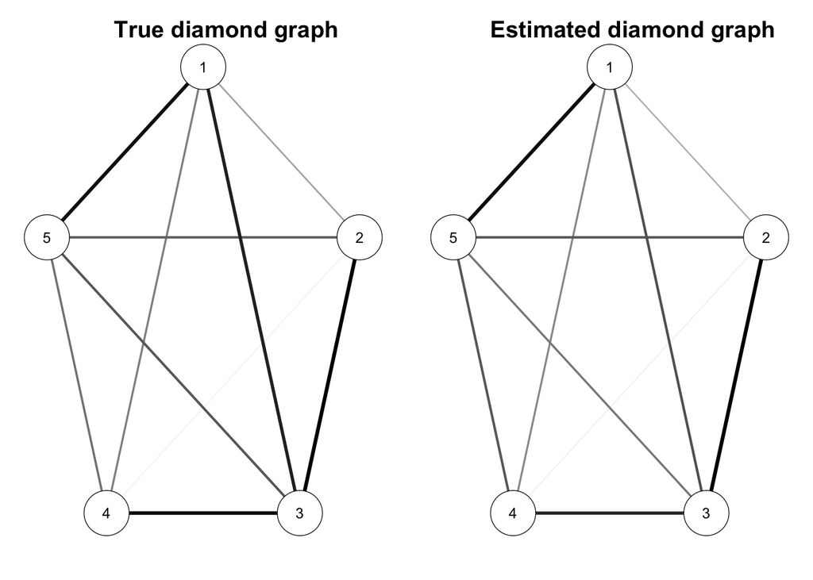

```r
# True adjancency matrix
W <- Lw - diag(diag(Lw))
library(qgraph)
par(mfrow = c(1, 2))
qgraph(W, esize = 5, edge.color = "black")
title("True diamond graph", line = 2.5)
qgraph(res$W, esize = 5, edge.color = "black")
title("Estimated diamond graph", line = 2.5)
```

```r
Lw_naive <- MASS::ginv(cov(Y))
rel_err <- c(proposed = spectralGraphTopology::relativeError(Lw, res$Lw),
             naive = spectralGraphTopology::relativeError(Lw, Lw_naive))
rel_err
```

```
#>   proposed      naive
#> 0.08869914 0.09224060
```

In this case, the naive estimation of the Laplacian matrix (i.e., generalized inverse of the sample covariance matrix) performs already quite well since the ratio $T/N$ is large enough 40 for the sample covariance matrix to be accurately estimated.

Let’s also look at the convergence of the objective function versus elapsed time:

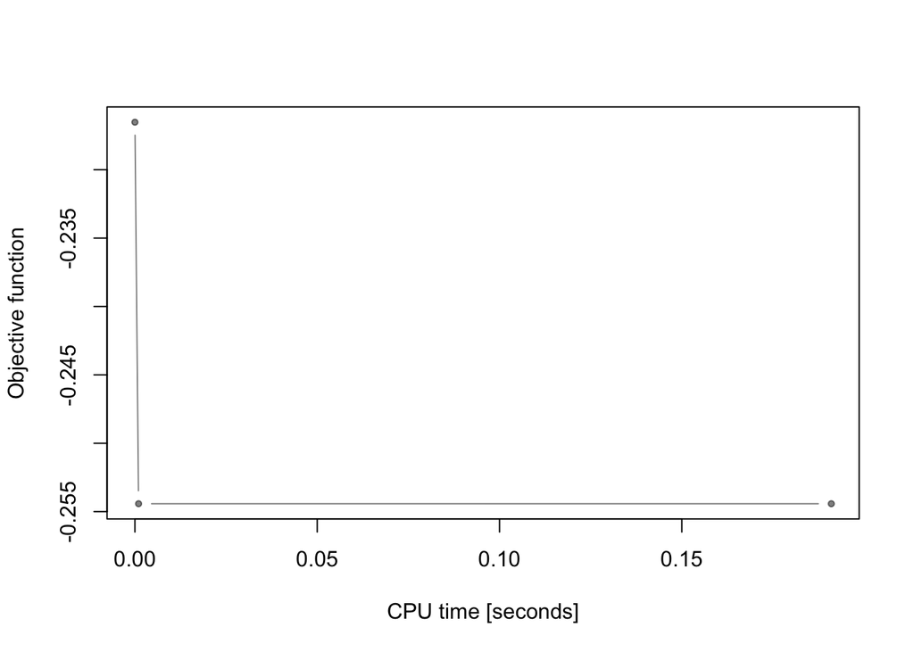

```r
plot(res$elapsed_time, res$obj_fun, type = "b", pch=19, cex=.6, col = scales::alpha("black", .5),
     xlab = "CPU time [seconds]", ylab = "Objective function")
```

## Illustrative example for K = 2

For K = 2 and $\beta = 100$, we can generate the Laplacian as a block diagonal matrix, as follows

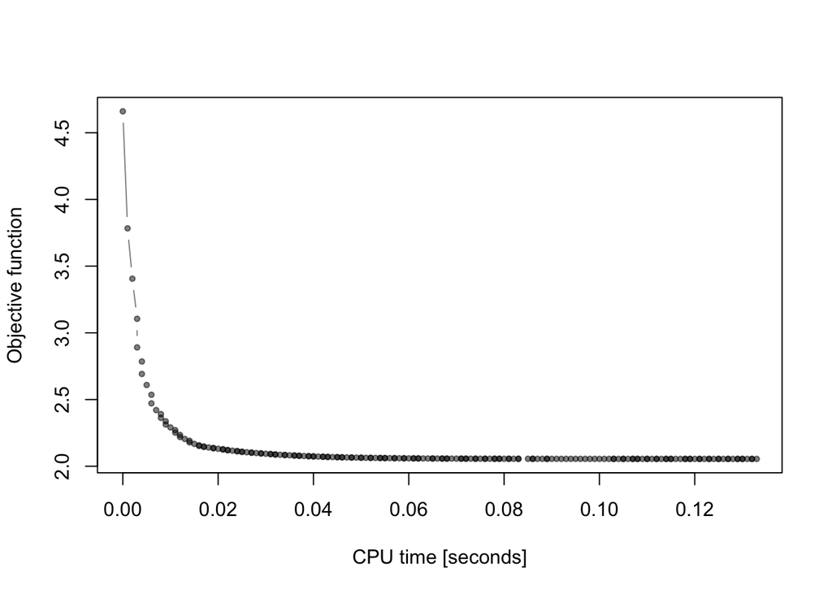

```r
library(spectralGraphTopology)
T <- 500
w1 <- runif(3)
w2 <- runif(6)
Lw1 <- L(w1)
Lw2 <- L(w2)
N1 <- ncol(Lw1)
N2 <- ncol(Lw2)
Lw <- blockDiag(Lw1, Lw2)
Y <- MASS::mvrnorm(T, rep(0, N1 + N2), MASS::ginv(Lw))
K <- 2
res <- learnGraphTopology(cov(Y), K, beta = 100)
plot(res$elapsed_time, res$obj_fun, type = "b", pch=19, cex=.6, col = scales::alpha("black", .5),
     xlab = "CPU time [seconds]", ylab = "Objective function")
```

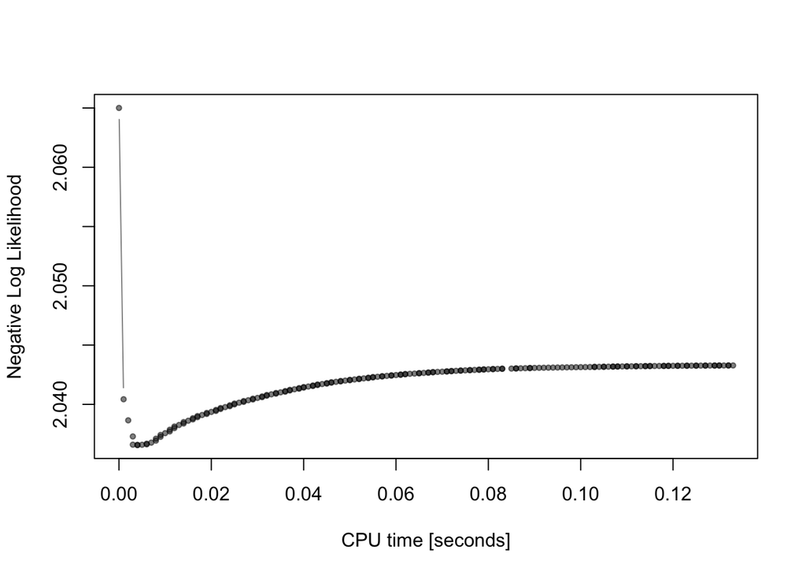

```r
plot(res$elapsed_time, res$loglike, type = "b", pch=19, cex=.6, col = scales::alpha("black", .5),
     xlab = "CPU time [seconds]", ylab = "Negative Log Likelihood")
```

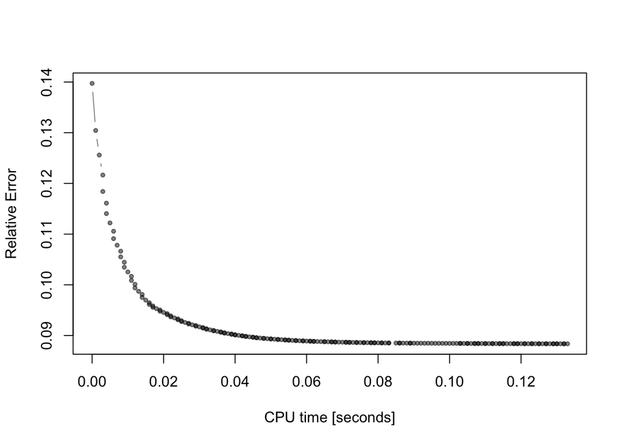

```r
rel_err_seq <- c()
w_seq <- res$w_seq
N_iter <- length(res$obj_fun)
for (i in 1:N_iter) {
  rel_err <- relativeError(Lw, L(w_seq[[i]]))
  rel_err_seq <- c(rel_err_seq, rel_err)
}
plot(res$elapsed_time, rel_err_seq, type = "b", pch=19, cex=.6, col = scales::alpha("black", .5),
     xlab = "CPU time [seconds]", ylab = "Relative Error")
```

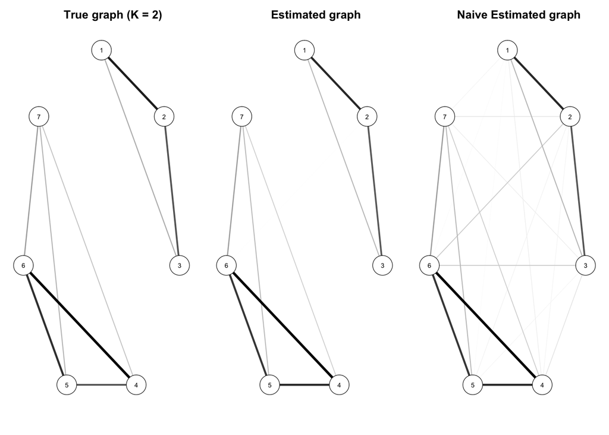

```r
W <- Lw - diag(diag(Lw))
Lw_naive <- MASS::ginv(cov(Y))
W_naive <- -(Lw_naive - diag(diag(Lw_naive)))

library(qgraph)
par(mfrow = c(1, 3))
qgraph(W, esize = 5, edge.color = "black")
title("True graph (K = 2)", line = 2.5)
qgraph(res$W, esize = 5, edge.color = "black")
title("Estimated graph", line = 2.5)
qgraph(W_naive, esize = 5, edge.color = "black")
title("Naive Estimated graph", line = 2.5)
```

# Explanation of the algorithms

## `learnGraphTopology`: Learning the topology of graph

# References

[1] J. Friedman, T. Hastie, and R. Tibshirani, “Sparse inverse covariance estimation with the graphical lasso,” *Biostatistics*, vol. 9, no. 3, pp. 432–441, 2008.